# Curso 7 Regression Models

## Aplicación de regresión lineal y mínimos cuadrados

Hasta ahora sólo hemos cosiderado hasta ahora la estimación, que es útil, pero también necesitamos saber cómo extender nuestras estimaciones a la población. Éste es el proceso de inferencia estadística. Nuestra aproximación a la inferencia estadística será a través de modelos estadísticos. Como mínimo, necesitamos algunas asunciones en la distribución de errores, nos focalizaremos en modelos sobre gausanidad.

Vamos a ver cómo hacer a través de mínimos cuadrados cálculos sobre al ecuación modificado el punto de corte con y (intercept) y la escala de la pendiente (por ejemplo porque tenga un valor muy alto).

Usamos el ejemplo del precio de los diamantes con respecto a sus quilates (carat)

Plot of the data

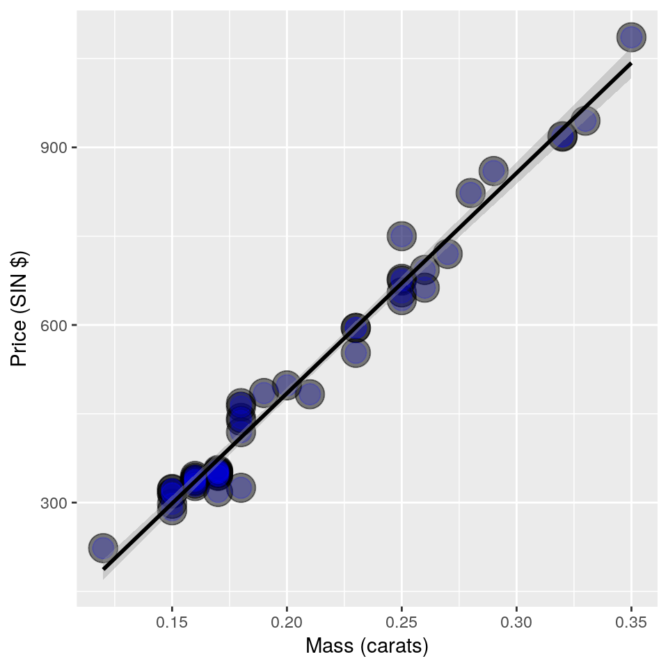

Intercept es el corte con X y el valor de carat es la pendiente de la recta, cada incremento de 1 kilate supone 3721$

```r
fit <- lm(price ~ carat, data = diamond)
coef(fit)
```

```
## (Intercept)       carat
##   -259.6259   3721.0249
```

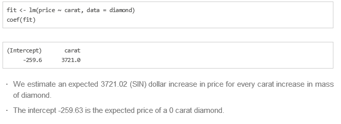

qownnotes-media-jiuSWl

No queremos para nada saber el precio de 0 kilates (-259.6), por lo que lo que podemos calcular el precio de la media de kilates para el valor de intercept Para hacer un cálculo aritmétco dentro de una función hay que poner I( )

Getting a more interpretable intercept

```r
fit2 <- lm(price ~ I(carat - mean(carat)), data = diamond)
coef(fit2)
```

```
##            (Intercept) I(carat - mean(carat))
##               500.0833              3721.0249
```

Ahora vemos que el cambio de 1 kilate es demasiado alto, por lo que nos puede interesar escalarlo para tener una mejor idea del valor

```r
fit3 <- lm(price ~ I(carat * 10), data = diamond)
coef(fit3)
```

```
##   (Intercept) I(carat * 10)
##     -259.6259      372.1025
```

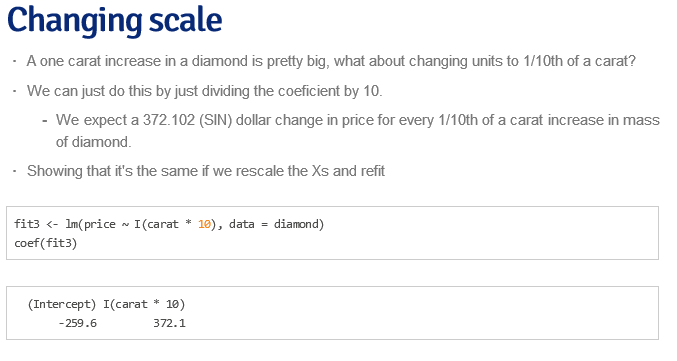

qownnotes-media-FUyJBN

Nuestro fin último es poder estimar el valor de nuevos diamantes, en este caso queremos inferir el precio de 3 diamantes

Predicting the price of a diamond

```r
newx <- c(0.16, 0.27, 0.34)
coef(fit)[1] + coef(fit)[2] * newx
```

```
## [1]  335.7381  745.0508 1005.5225
```

```r
predict(fit, newdata = data.frame(carat = newx))
```

```
##         1         2         3
##  335.7381  745.0508 1005.5225
```

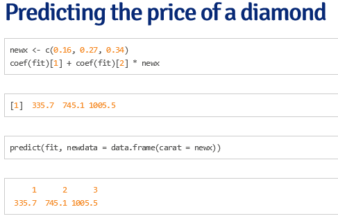

qownnotes-media-xCTQRV

Si hacemos predict(fit) nos devolverá únicamente los valores predecidos para las x del dataset

Podemos mostrar los valores que hemos predecido en la misma gráfica

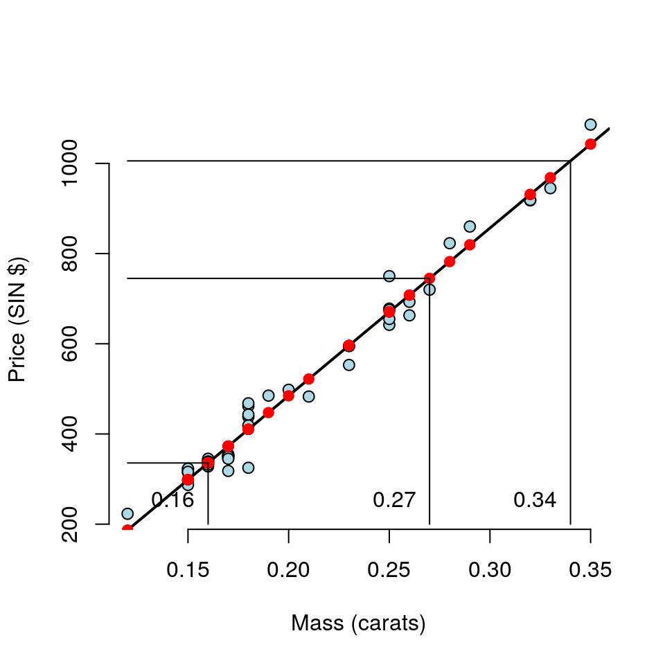

Ejercicios

In this lesson we’ll illustrate that regression in many variables amounts to a series of regressions in one. Using regression in one variable, we’ll show how to eliminate any chosen regressor, thus reducing a regression in N variables, to a regression in N-1. Hence, if we know how to do a regression in 1 variable, we can do a regression in 2. Once we know how to do a regression in 2 variables, we can do a regression in 3, and so on. We begin with the galton data and a review of eliminating the intercept by subtracting the means.

When we perform a regression in one variable, such as lm(child ~ parent, galton), we get two coefficients, a slope and an intercept. The intercept is really the coefficient of a special regressor which has the same value, 1, at every sample. The function, lm, includes this regressor by default.

We’ll demonstrate by substituting an all-ones regressor of our own. This regressor must have the same number of samples as galton (928.) Create such an object and name it ones, using ones <- rep(1, nrow(galton)), or some equivalent expression.

> ones <- rep(1, nrow(galton))

You’re the best!

The galton data has already been loaded. The default intercept can be excluded by using -1 in the formula. Perform a regression which substitutes our regressor, ones, for the default using lm(child ~ ones + parent -1, galton). Since we want the result to print, don’t assign it to a variable.

> lm(child ~ ones + parent -1, galton)

Call: lm(formula = child ~ ones + parent - 1, data = galton)

Coefficients: ones parent  
23.9415 0.6463

That’s the answer I was looking for.

The coefficient of ones is 23.9415. Now use the default, lm(child ~ parent, galton), to show the intercept has the same value. This time, DO NOT suppress the intercept with -1.

> lm(child ~ parent, galton)

Call: lm(formula = child ~ parent, data = galton)

Coefficients: (Intercept) parent  
23.9415 0.6463

Excellent job!

The regression in one variable given by lm(child ~ parent, galton) really involves two regressors, the variable, parent, and a regressor of all ones.

1: True 2: False

Selection: 1

All that practice is paying off!

In earlier lessons we demonstrated that the regression line given by lm(child ~ parent, galton) goes through the point x=mean(parent), y=mean(child). We also showed that if we subtract the mean from each variable, the regression line goes through the origin, x=0, y=0, hence its intercept is zero. Thus, by subtracting the means, we eliminate one of the two regressors, the constant, leaving just one, parent. The coefficient of the remaining regressor is the slope.

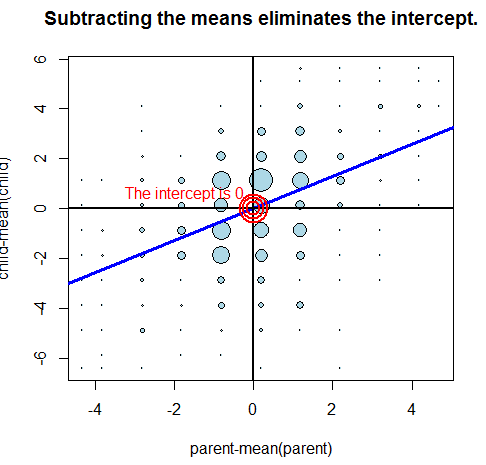

qownnotes-media-bLHzWL

Subtracting the means to eliminate the intercept is a special case of a general technique which is sometimes called Gaussian Elimination. As it applies here, the general technique is to pick one regressor and to replace all other variables by the residuals of their regressions against that one.

…

|======================================== | 35%

Suppose, as claimed, that subtracting a variable’s mean is a special case of replacing the variable with a residual. In this special case, it would be the residual of a regression against what?

1: The variable itself 2: The outcome 3: The constant, 1

Selection: 3

That’s the answer I was looking for.

|============================================= | 38%

The mean of a variable is the coefficient of its regression against the constant, 1. Thus, subtracting the mean is equivalent to replacing a variable by the residual of its regression against 1. In an R formula, the constant regressor can be represented by a 1 on the right hand side. Thus, the expression, lm(child ~ 1, galton), regresses child against the constant, 1. Recall that in the galton data, the mean height of a child was 68.09 inches. Use lm(child ~ 1, galton) to compare the resulting coefficient (the intercept) and the mean height of 68.09. Since we want the result to print, don’t assign it a name.

> lm(child ~ 1, galton)

Call: lm(formula = child ~ 1, data = galton)

Coefficients: (Intercept)  
68.09

That’s a job well done!

The mean of a variable is equal to its regression against the constant, 1.

1: True 2: False

Selection: 1

All that hard work is paying off!

To illustrate the general case we’ll use the trees data from the datasets package. The idea is to predict the Volume of timber which a tree might produce from measurements of its Height and Girth. To avoid treating the intercept as a special case, we have added a column of 1’s to the data which we shall use in its place. Please take a moment to inspect the data using either View(trees) or head(trees).

> head(trees) Constant Girth Height Volume 1 1 8.3 70 10.3 2 1 8.6 65 10.3 3 1 8.8 63 10.2 4 1 10.5 72 16.4 5 1 10.7 81 18.8 6 1 10.8 83 19.7

Excellent job!

A file of relevant code has been copied to your working directory and sourced. The file, elimination.R, should have appeared in your editor. If not, please open it manually.

```
# Regress the given variable on the given predictor,
# suppressing the intercept, and return the residual.
regressOneOnOne <- function(predictor, other, dataframe){
  # Point A. Create a formula such as Girth ~ Height -1
  formula <- paste0(other, " ~ ", predictor, " - 1")
  # Use the formula in a regression and return the residual.
  resid(lm(formula, dataframe))
}

# Eliminate the specified predictor from the dataframe by
# regressing all other variables on that predictor
# and returning a data frame containing the residuals
# of those regressions.
eliminate <- function(predictor, dataframe){
  # Find the names of all columns except the predictor.
  others <- setdiff(names(dataframe), predictor)
  # Calculate the residuals of each when regressed against the given predictor
  temp <- sapply(others, function(other)regressOneOnOne(predictor, other, dataframe))
  # sapply returns a matrix of residuals; convert to a data frame and return.
  as.data.frame(temp)
}
```

Selection: 3

That’s correct!

The remaining function, eliminate, applies regressOneOnOne to all variables except a given predictor and collects the residuals in a data frame. We’ll first show that when we eliminate one regressor from the data, a regression on the remaining will produce their correct coefficients. (Of course, the coefficient of the eliminated regressor will be missing, but more about that later.)

For reference, create a model named fit, based on all three regressors, Girth, Height, and Constant, and assign the result to a variable named fit. Use an expression such as fit <- lm(Volume ~ Girth + Height + Constant -1, trees). Don’t forget the -1, and be sure to name the model fit for later use.

> fit <- lm(Volume ~ Girth + Height + Constant -1, trees)

Great job!

Now let’s eliminate Girth from the data set. Call the reduced data set trees2 to indicate it has only 2 regressors. Use the expression trees2 <- eliminate(“Girth”, trees).

> trees2 <- eliminate(“Girth”, trees)

Keep working like that and you’ll get there!

Use head(trees2) or View(trees2) to inspect the reduced data set.

> head(trees2) Constant Height Volume 1 0.4057735 24.38809 -9.793826 2 0.3842954 17.73947 -10.520109 3 0.3699767 14.64038 -11.104298 4 0.2482677 14.29818 -9.019900 5 0.2339490 22.19910 -7.104089 6 0.2267896 23.64956 -6.446183

Your dedication is inspiring!

Why, in trees2, is the Constant column not constant?

1: Computational precision was insufficient. 2: The constant, 1, has been replaced by its residual when regressed against Girth. 3: There must be some mistake

Selection: View(trees2) Enter an item from the menu, or 0 to exit Selection: 2

Keep working like that and you’ll get there!

Now create a model, called fit2, using the reduced data set. Use an expression such as fit2 <- lm(Volume ~ Height + Constant -1, trees2). Don’t forget to use -1 in the formula.

> fit2 <- lm(Volume ~ Height + Constant-1, trees2)

Excellent work!

Use the expression lapply(list(fit, fit2), coef) to print coefficients of fit and fit2 for comparison.

> lapply(list(fit, fit2), coef) [[1]] Girth Height Constant 4.7081605 0.3392512 -57.9876589

[[2]] Height Constant 0.3392512 -57.9876589

You are amazing!

The coefficient of the eliminated variable is missing, of course. One way to get it would be to go back to the original data, trees, eliminate a different regressor, such as Height, and do another 2 variable regession, as above. There are much more efficient ways, but efficiency is not the point of this demonstration. We have shown how to reduce a regression in 3 variables to a regression in 2. We can go further and eliminate another variable, reducing a regression in 2 variables to a regression in 1.

Here is the final step. We have used eliminate(“Height”, trees2) to reduce the data to the outcome, Volume, and the Constant regressor. We have regressed Volume on Constant, and printed the coefficient as shown in the command above the answer. As you can see, the coefficient of Constant agrees with previous values.

Call: lm(formula = Volume ~ Constant - 1, data = eliminate(“Height”, trees2))

Coefficients: Constant  
-57.99

Suppose we were given a multivariable regression problem involving an outcome and N regressors, where N > 1. Using only single-variable regression, how can the problem be reduced to a problem with only N-1 regressors?

1: Subtract the mean from the outcome and each regressor. 2: Pick any regressor and replace the outcome and all other regressors by their residuals against the chosen one.

Selection: 2

You are really on a roll!

We have illustrated that regression in many variables amounts to a series of regressions in one. The actual algorithms used by functions such as lm are more efficient, but are computationally equivalent to what we have done. That is, the algorithms use equivalent steps but combine them more efficiently and abstractly. This completes the lesson.

## Varianza de Residuos

Los residuos representan la variación que no ha podido ser explicada por nuestro modelo. Es importante notar la diferencia entre residuos y errores. Los errores son errores reales no observados desde los coeficientes conocidos, mientras que los residuos son errores observables desde los coeficientes observados. De alguna manera, los residuos son la estimación de los errores

Los residuos son la diferencia entre la estimación de las y y el valor real que en conjunto de datos. Tenemos que recordar que para que la regresión lineal sea aplicable, hay una serie de hipótesis como que la suma de los residuos es cero y que la varianza de los residuos es uniforme

Recordamos que si hacemos predict(fit) obtenemos los valores de la predicción de las x en lugar de su valor real, aquí verermos cómo la diferencia entre calcular los residuos con resid() y calculándolo a mano, la máxima diferencia entre ambos resultados es muy cercano a 0

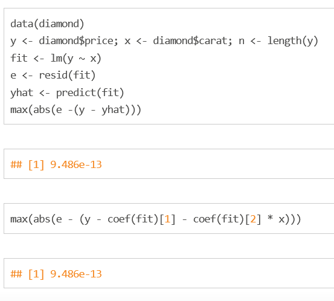

qownnotes-media-pNWqxF

Además podemos comprobar una de nuestras hipótesis para poder aplcar la regresión lineal, y es que la suma de los reiduos es 0, así como si lo multiplicamos por x

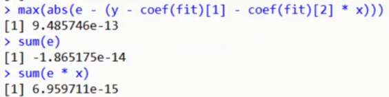

qownnotes-media-kbAnjm

```
{r, echo = FALSE, fig.height=5, fig.width=5}
plot(diamond$carat, diamond$price,
     xlab = "Mass (carats)",
     ylab = "Price (SIN $)",
     bg = "lightblue",
     col = "black", cex = 2, pch = 21,frame = FALSE)
abline(fit, lwd = 2)
for (i in 1 : n)
  lines(c(x[i], x[i]), c(y[i], yhat[i]), col = "red" , lwd = 2)
```

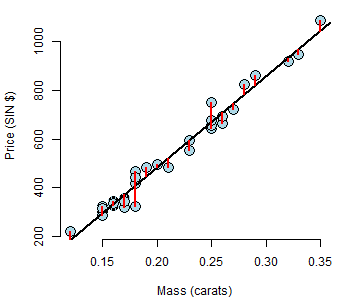

qownnotes-media-DuQGjF

Muchas veces los residuos nos permiten ver patrones en los datos, por lo que es muy útil ponerlo en el eje de las x

[output not shown]

Este no es el caso ya que nuestro modelo se ajusta muy bien, pero por ejemplo nos ha servido para ver que hay muchos casos en los que para un mismo tamaño, no es siempre el mismo precio

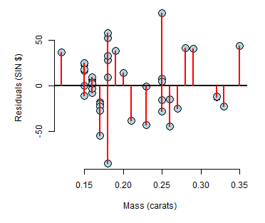

qownnotes-media-QLKGdA

Hay veces, que aunque los datos no sean lineales, mostrar su recta de regresión es muy útil para detectar su patrón, aunque la recta o no nos sirva para hacer una predicción adecuada (the model doesnt fit)

No linear data (metemos sen() en la función y introduciendo también algo de ruido normalizado, en las x una distribución uniforme runif,)

```
{r, echo = FALSE, fig.height=5, fig.width=5}
x = runif(100, -3, 3); y = x + sin(x) + rnorm(100, sd = .2);
library(ggplot2)
g = ggplot(data.frame(x = x, y = y), aes(x = x, y = y))
g = g + geom_smooth(method = "lm", colour = "black")
g = g + geom_point(size = 7, colour = "black", alpha = 0.4)
g = g + geom_point(size = 5, colour = "red", alpha = 0.4)
g
```

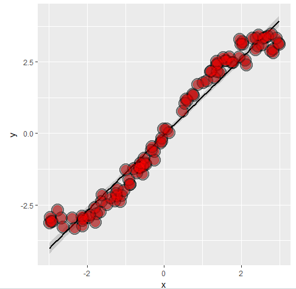

qownnotes-media-NprLkt

Así a primera vista nos podría parecer un modelo acertado, pero si observamos de cerca sus residuos:

```
{r, echo = FALSE, fig.height=5, fig.width=5}
g = ggplot(data.frame(x = x, y = resid(lm(y ~ x))),
           aes(x = x, y = y))
g = g + geom_hline(yintercept = 0, size = 2);
g = g + geom_point(size = 7, colour = "black", alpha = 0.4)
g = g + geom_point(size = 5, colour = "red", alpha = 0.4)
g = g + xlab("X") + ylab("Residual")
g
```

Vemos que realmente hay mucha variabilidad respecto a la recta de regresión

[figure not shown]

qownnotes-media-SuXmwZ

E incluso vemos el patrón mucho más claramente en los datos

[figure not shown]

qownnotes-media-KBfCUc

Otra de las cosas que podemos comprobar es si se cumple la segunda hipótesis, que es que la distribución de la varianza de los residuos sea uniforme. esto lo vamos a comprobar con la heterocedasticidad

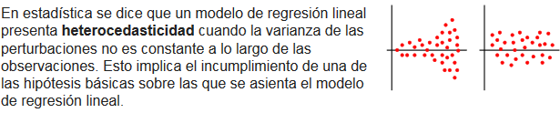

qownnotes-media-uMHevD

Aquí aparentemente vemos que la recta es muy acertada

```
{r, echo = FALSE, fig.height=4.5, fig.width=4.5}
x <- runif(100, 0, 6); y <- x + rnorm(100,  mean = 0, sd = .001 * x);
g = ggplot(data.frame(x = x, y = y), aes(x = x, y = y))
g = g + geom_smooth(method = "lm", colour = "black")
g = g + geom_point(size = 7, colour = "black", alpha = 0.4)
g = g + geom_point(size = 5, colour = "red", alpha = 0.4)
g
```

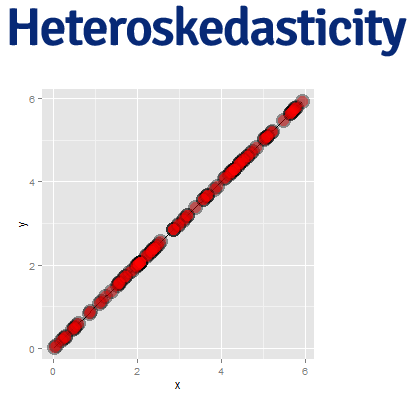

qownnotes-media-oYqzkP

Sin embargo si echamos un vistazo más profundo a los residuos, vemos que su distribución no es uniforme, si no que crece con las x, esto es lo que se llama heterocedasticidad, y lo conseguimos metiendo las x dentro de la función rnorm de las y

y <- x + rnorm(100, mean = 0, sd = .001 * x)

```
{r, echo = FALSE, fig.height=4.5, fig.width=4.5}
g = ggplot(data.frame(x = x, y = resid(lm(y ~ x))),
           aes(x = x, y = y))
g = g + geom_hline(yintercept = 0, size = 2);
g = g + geom_point(size = 7, colour = "black", alpha = 0.4)
g = g + geom_point(size = 5, colour = "red", alpha = 0.4)
g = g + xlab("X") + ylab("Residual")
g
```

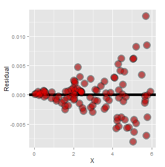

qownnotes-media-NyOltz

Volviendo al ejempo de los diamantes, vamos a añadir al dataset los residuos de cada par de valores, y vamos a dibujarlos frente a los kilates, los residuos tendrán siempre las unidades de las y

```
{r, echo = FALSE, fig.height=4.5, fig.width=4.5}
diamond$e <- resid(lm(price ~ carat, data = diamond))
g = ggplot(diamond, aes(x = carat, y = e))
g = g + xlab("Mass (carats)")
g = g + ylab("Residual price (SIN $)")
g = g + geom_hline(yintercept = 0, size = 2)
g = g + geom_point(size = 7, colour = "black", alpha=0.5)
g = g + geom_point(size = 5, colour = "blue", alpha=0.2)
g
```

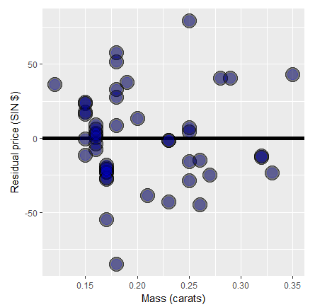

qownnotes-media-ByaBpa

Lo primero que hacemos es calcular los residuos frente a la media del precio (esto es frente al interception), el otro vector es ls residuos frente a la recta de regresión

Luego creo dos facores, uno de interception y otro de inter y slope

```
{r, echo = FALSE, fig.height=4.5, fig.width=4.5}
e = c(resid(lm(price ~ 1, data = diamond)),
      resid(lm(price ~ carat, data = diamond)))
fit = factor(c(rep("Itc", nrow(diamond)),
               rep("Itc, slope", nrow(diamond))))
g = ggplot(data.frame(e = e, fit = fit), aes(y = e, x = fit, fill = fit))
g = g + geom_dotplot(binaxis = "y", size = 2, stackdir = "center", binwidth = 20)
g = g + xlab("Fitting approach")
g = g + ylab("Residual price")
g
```

La varianza de los residuos por tanto será la suma al cuadrado de los residuos dividido n

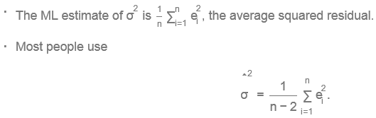

qownnotes-media-VHpgFq

La razón por la que se resta 2 es por quitarle 2 grados de libertad, uno por conocer el final (intercerp) como con la varianza y otro grado de libertad por la covarianza entre x e y

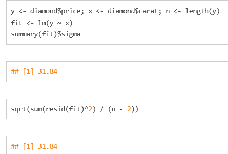

qownnotes-media-QdNeXf

En el primer gráfico vemos la variación en el precio de los diamantes alrededor de la media del precio.

En el gráfico azul vemos la variación frente a la linea de regresión

[figure not shown]

qownnotes-media-xBrfKR

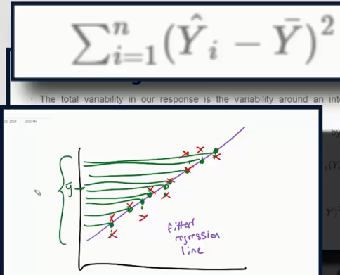

qownnotes-media-lbWthX

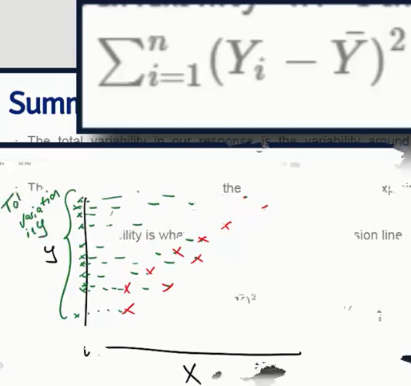

qownnotes-media-fWNVhO

R^2

Es el porcentaje total de la variabilidad explicada por la relacción lineal con el predictor

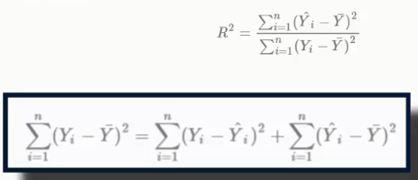

qownnotes-media-ALluas

En los siguientes ejemplos vamos a ver cómo a pesar de que todo indica una buena realacción lineal, en realidad no la hay

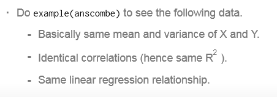

qownnotes-media-ISIpjA

En el primer gráfico se ve que hay mucho ruido, en el segundo que es una curva que no se ajusta, en el tercero hay un outlier que interfiere mucho y en el cuarto hay un punto que hace que se degenere.

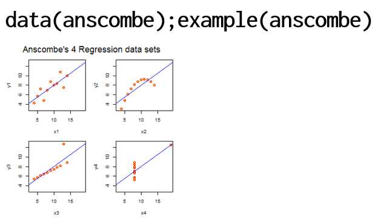

qownnotes-media-hvZcHw

Ejercicios

As shown in the slides, residuals are useful for indicating how well data points fit a statistical model. They “can be thought of as the outcome (Y) with the linear association of the predictor (X) removed. One differentiates residual variation (variation after removing the predictor) from systematic variation (variation explained by the regression model).“

It can also be shown that, given a model, the maximum likelihood estimate of the variance of the random error is the average squared residual. However, since our linear model with one predictor requires two parameters we have only (n-2) degrees of freedom. Therefore, to calculate an “average” squared residual to estimate the variance we use the formula 1/(n-2) * (the sum of the squared residuals). If we divided the sum of the squared residuals by n, instead of n-2, the result would give a biased estimate.

To see this we’ll use our favorite Galton height data. First regenerate the regression line and call it fit. Use the R function lm and recall that by default its first argument is a formula such as “child ~ parent” and its second is the dataset, in this case galton.

> lm(child ~ parent,galton)

Call: lm(formula = child ~ parent, data = galton)

Coefficients: (Intercept) parent  
23.9415 0.6463

That’s not exactly what I’m looking for. Try again. Or, type info() for more options.

Type “fit <- lm(child ~ parent, galton)” at the R prompt.

> fit <- lm(child ~ parent, galton)

That’s the answer I was looking for.

First, we’ll use the residuals (fit$residuals) of our model to estimate the standard deviation (sigma) of the error. We’ve already defined n for you as the number of points in Galton’s dataset (928).

Calculate the sum of the squared residuals divided by the quantity (n-2). Then take the square root.

> sqrt(sum(fit$residuals^2) / (n - 2)) [1] 2.238547

Great job!

Now look at the “sigma” portion of the summary of fit, “summary(fit)$sigma”.

> summary(fit)$sigma [1] 2.238547

All that hard work is paying off!

Pretty cool, huh?

Another cool thing - take the sqrt of “deviance(fit)/(n-2)” at the R prompt.

> sqrt(deviance(fit)/(n-2)) [1] 2.238547

Excellent work!

Another useful fact shown in the slides was

Total Variation = Residual Variation + Regression Variation

Recall the beauty of the slide full of algebra which proved this fact. It had a bunch of Y’s, some with hats and some with bars and several summations of squared values. The Y’s with hats were the estimates provided by the model. (They were on the regression line.) The Y with the bar was the mean or average of the data. Which sum of squared term represented Total Variation?

1: Yi_hat-mean(Yi) 2: Yi-mean(Yi) 3: Yi-Yi_hat

Selection: 2

Nice work!

Which sum of squared term represents Residual Variation?

1: Yi_hat-mean(Yi) 2: Yi-Yi_hat 3: Yi-mean(Yi)

Selection: 2

The term R^2 represents the percent of total variation described by the model, the regression variation (the term we didn’t ask about in the preceding multiple choice questions). Also, since it is a percent we need a ratio or fraction of sums of squares. Let’s do this now for our Galton data.

We’ll start with easy steps. Calculate the mean of the children’s heights and store it in a variable called mu. Recall that we reference the childrens’ heights with the expression ‘galton$child’ and the parents’ heights with the expression ‘galton$parent’.

> mu <- mean(galton$child)

That’s the answer I was looking for.

Recall that centering data means subtracting the mean from each data point. Now calculate the sum of the squares of the centered children’s heights and store the result in a variable called sTot. This represents the Total Variation of the data.

> sTot <- sum((galton$child-mu)^2)

Excellent job!

Now create the variable sRes. Use the R function deviance to calculate the sum of the squares of the residuals. These are the distances between the children’s heights and the regression line. This represents the Residual Variation.

> sRes <- deviance(fit)

Perseverance, that’s the answer.

Finally, the ratio sRes/sTot represents the percent of total variation contributed by the residuals. To find the percent contributed by the model, i.e., the regression variation, subtract the fraction sRes/sTot from 1. This is the value R^2.

> 1 - sRes/sTot [1] 0.2104629

Your dedication is inspiring!

For fun you can compare your result to the values shown in summary(fit)$r.squared to see if it looks familiar. Do this now.

> summary(fit)$r.squared [1] 0.2104629

You are doing so well!

To see some real magic, compute the square of the correlation of the galton data, the children and parents. Use the R function cor.

> cor(galton$child,galton$parent)^2 [1] 0.2104629

Keep working like that and you’ll get there!

We’ll now summarize useful facts about R^2. It is the percentage of variation explained by the regression model. As a percentage it is between 0 and 1. It also equals the sample correlation squared. However, R^2 doesn’t tell the whole story.

## Inferencia

Es el proceso de sacar conclusiones acerca de la población desde una muestra. En inferencia estadística, debemos ser siempre conscientes de la incertidumbre en nuestras estimaciones concienzudamente. Los test de hipótesis e intervalos de confianza son las formas más comunes de inferencia estadística.

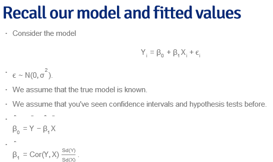

qownnotes-media-SZlQQz

Podemos calcular todo a mano para ver que todo cuadra

```
{r}
library(UsingR); data(diamond)
y <- diamond$price; x <- diamond$carat; n <- length(y)
beta1 <- cor(y, x) * sd(y) / sd(x)
beta0 <- mean(y) - beta1 * mean(x)
e <- y - beta0 - beta1 * x
sigma <- sqrt(sum(e^2) / (n-2))
ssx <- sum((x - mean(x))^2)
seBeta0 <- (1 / n + mean(x) ^ 2 / ssx) ^ .5 * sigma
seBeta1 <- sigma / sqrt(ssx)
tBeta0 <- beta0 / seBeta0; tBeta1 <- beta1 / seBeta1
pBeta0 <- 2 * pt(abs(tBeta0), df = n - 2, lower.tail = FALSE)
pBeta1 <- 2 * pt(abs(tBeta1), df = n - 2, lower.tail = FALSE)
coefTable <- rbind(c(beta0, seBeta0, tBeta0, pBeta0), c(beta1, seBeta1, tBeta1, pBeta1))
colnames(coefTable) <- c("Estimate", "Std. Error", "t value", "P(>|t|)")
rownames(coefTable) <- c("(Intercept)", "x")
```

Comparamos los resultados del calculo a mano y el calculo con lm

```
{r}
coefTable
fit <- lm(y ~ x);
summary(fit)$coefficients
```

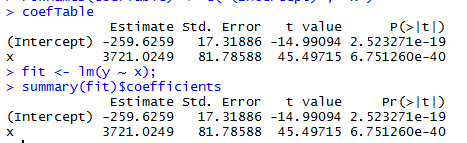

qownnotes-media-PhOFwb

Y finalmente hacemos el cálculo del intervalo de confianza de nuestra estimación

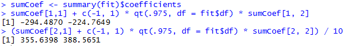

qownnotes-media-bsQtRI

**Podemos decir por tanto que con un 95% de probabilidad, el incremento de precio sobre 0.1 kilates en diamantes estará entre 355.63 y 388.56**

```
{r, fig.height=5, fig.width==5, echo = FALSE, results='hide'}
library(ggplot2)
newx = data.frame(x = seq(min(x), max(x), length = 100))
p1 = data.frame(predict(fit, newdata= newx,interval = ("confidence")))
p2 = data.frame(predict(fit, newdata = newx,interval = ("prediction")))
p1$interval = "confidence"
p2$interval = "prediction"
p1$x = newx$x
p2$x = newx$x
dat = rbind(p1, p2)
names(dat)[1] = "y"

g = ggplot(dat, aes(x = x, y = y))
g = g + geom_ribbon(aes(ymin = lwr, ymax = upr, fill = interval), alpha = 0.2)
g = g + geom_line()
g = g + geom_point(data = data.frame(x = x, y=y), aes(x = x, y = y), size = 4)
g
```

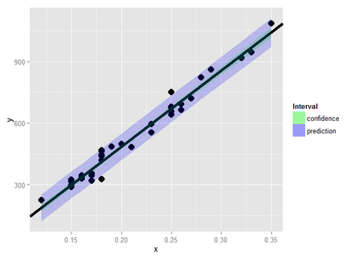

qownnotes-media-HxdQrL

In this lesson, we’ll look at some examples of regression models with more than one variable. We’ll begin with the Swiss data which we’ve taken the liberty to load for you. This data is part of R’s datasets package. It was gathered in 1888, a time of demographic change in Switzerland, and measured six quantities in 47 French-speaking provinces of Switzerland. We used the code from the slides (the R function pairs) to display here a 6 by 6 array of scatterplots showing pairwise relationships between the variables. All of the variables, except for fertility, are proportions of population. For example, “Examination” shows the percentage of draftees receiving the highest mark on an army exam, and “Education” the percentage of draftees with education beyond primary school.

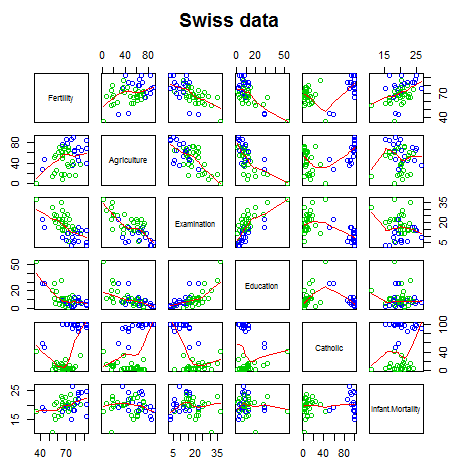

qownnotes-media-zSGDCG

First, use the R function lm to generate the linear model “all” in which Fertility is the variable dependent on all the others. Use the R shorthand “.” to represent the five independent variables in the formula passed to lm. Remember the data is “swiss”.

> all <- lm(Fertility ~ ., swiss)

Now look at the summary of the linear model all.

> summary(all)

Call: lm(formula = Fertility ~ ., data = swiss)

Residuals: Min 1Q Median 3Q Max -15.2743 -5.2617 0.5032 4.1198 15.3213

Residual standard error: 7.165 on 41 degrees of freedom Multiple R-squared: 0.7067, Adjusted R-squared: 0.671 F-statistic: 19.76 on 5 and 41 DF, p-value: 5.594e-10

You are quite good my friend!

The “*" at the far end of the row indicates that the influence of Agriculture on Fertility is significant. At what alpha level is the t-test of Agriculture significant?

1: 0.1 2: 0.05 3: 0.01 4: R doesn’t say

Selection: Enter an item from the menu, or 0 to exit Selection: 2

Excellent work!

Now generate the summary of another linear model (don’t store it in a new variable) in which Fertility depends only on agriculture.

> all <- lm(Fertility ~ Agriculture, swiss)

Almost! Try again. Or, type info() for more options.

Type “summary(lm(Fertility ~ Agriculture, swiss))” at the R prompt.

> summary(lm(Fertility ~ Agriculture, swiss))

Call: lm(formula = Fertility ~ Agriculture, data = swiss)

Residuals: Min 1Q Median 3Q Max -25.5374 -7.8685 -0.6362 9.0464 24.4858

Residual standard error: 11.82 on 45 degrees of freedom Multiple R-squared: 0.1247, Adjusted R-squared: 0.1052 F-statistic: 6.409 on 1 and 45 DF, p-value: 0.01492

All that hard work is paying off!

1: 0.19420 2: 60.30438 3: 0.07671 4: *

Selection: 1

Keep up the great work!

The interesting point is that the sign of the Agriculture coefficient changed from negative (when all the variables were included in the model) to positive (when the model only considered Agriculture). Obviously the presence of the other factors affects the influence Agriculture has on Fertility.

Let’s consider the relationship between some of the factors. How would you expect level Education and performance on an Examination to be related?

1: They would be uncorrelated 2: They would be correlated 3: I would not be able to guess without more information

Selection: 2

You nailed it! Good job!

Now check your intuition with the R command “cor”. This computes the correlation between Examination and Education.

> cor(swiss$Examination,swiss$Education) [1] 0.6984153

Perseverance, that’s the answer.

The correlation of .6984 shows the two are correlated. Now find the correlation between Agriculture and Education.

> cor(swiss$Agriculture,swiss$Education) [1] -0.6395225

You are amazing!

The negative correlation (-.6395) between Agriculture and Education might be affecting Agriculture’s influence on Fertility. I’ve loaded and sourced the file swissLMs.R in your working directory. In it is a function makelms() which generates a sequence of five linear models. Each model has one more independent variable than the preceding model, so the first has just one independent variable, Agriculture, and the last has all 5. I’ve tried loading the source code in your editor. If I haven’t done this, open the file manually so you can look at the code.

```
makelms <- function(){
  # Store the coefficient of linear models with different independent variables
  cf <- c(coef(lm(Fertility ~ Agriculture, swiss))[2],
          coef(lm(Fertility ~ Agriculture + Catholic,swiss))[2],
          coef(lm(Fertility ~ Agriculture + Catholic + Education,swiss))[2],
          coef(lm(Fertility ~ Agriculture + Catholic + Education + Examination,swiss))[2],
          coef(lm(Fertility ~ Agriculture + Catholic + Education + Examination +Infant.Mortality, swiss))[2])
  print(cf)
}


# Regressor generation process 1.
rgp1 <- function(){
  print("Processing. Please wait.")
  # number of samples per simulation
  n <- 100
  # number of simulations
  nosim <- 1000
  # set seed for reproducability
  set.seed(4321)
  # Point A:
  x1 <- rnorm(n)
  x2 <- rnorm(n)
  x3 <- rnorm(n)
  # Point B:
  betas <- sapply(1 : nosim, function(i)makelms(x1, x2, x3))
  round(apply(betas, 1, var), 5)
}

# Regressor generation process 2.
rgp2 <- function(){
  print("Processing. Please wait.")
  # number of samples per simulation
  n <- 100
  # number of simulations
  nosim <- 1000
  # set seed for reproducability
  set.seed(4321)
  # Point C:
  x1 <- rnorm(n)
  x2 <- x1/sqrt(2) + rnorm(n) /sqrt(2)
  x3 <- x1 * 0.95 + rnorm(n) * sqrt(1 - 0.95^2)
  # Point D:
  betas <- sapply(1 : nosim, function(i)makelms(x1, x2, x3))
  round(apply(betas, 1, var), 5)
}
```

## TEST2

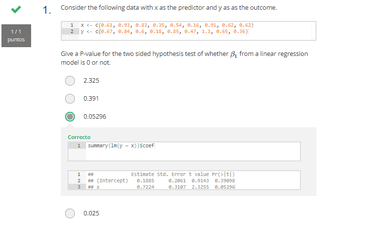

qownnotes-media-FATtcx

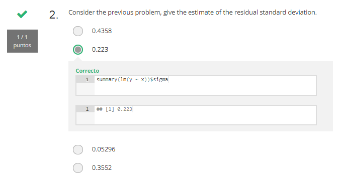

qownnotes-media-FRaEUb

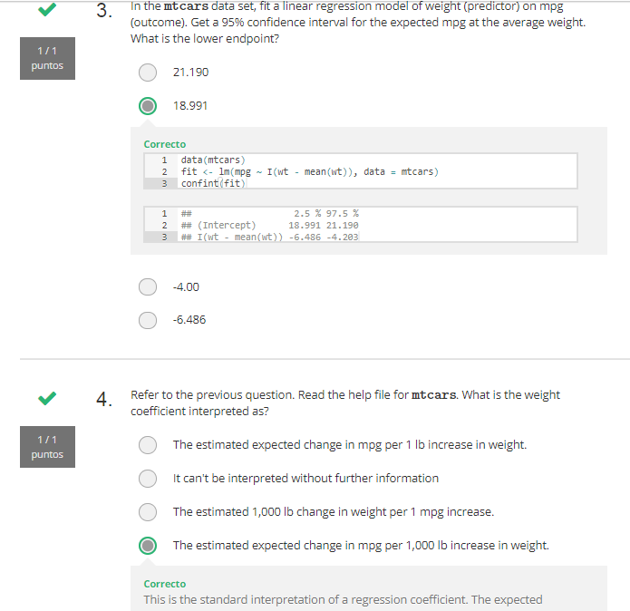

qownnotes-media-vvKXCO

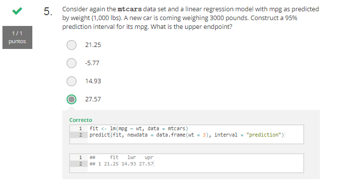

qownnotes-media-vvjBvz

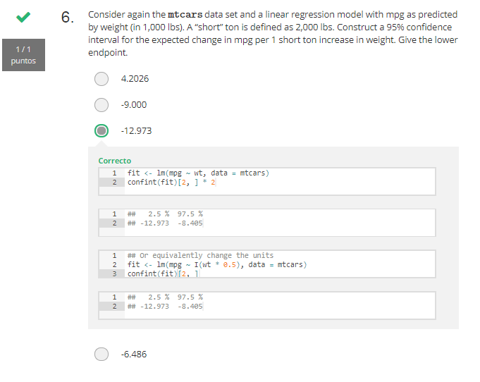

qownnotes-media-ytKPiJ

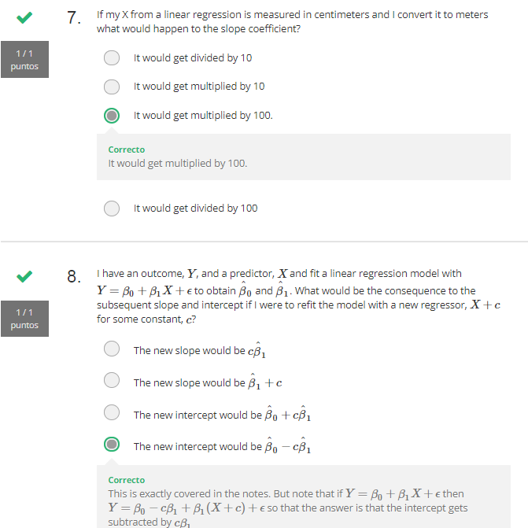

qownnotes-media-GXWwfn

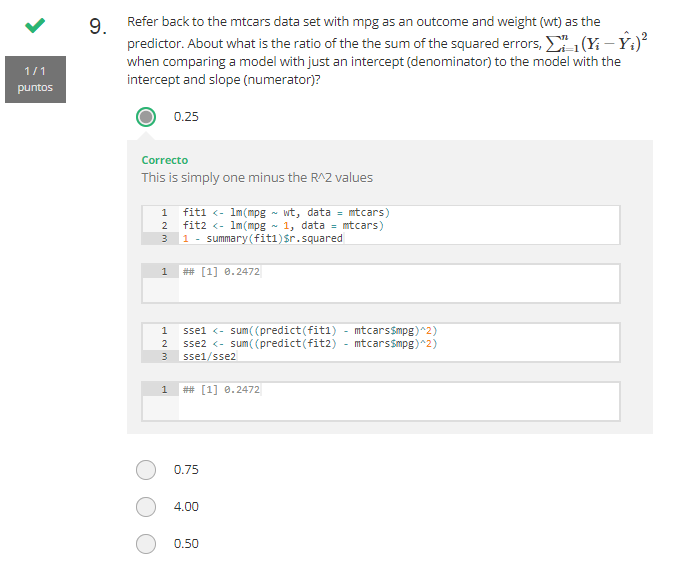

qownnotes-media-BwKEvy

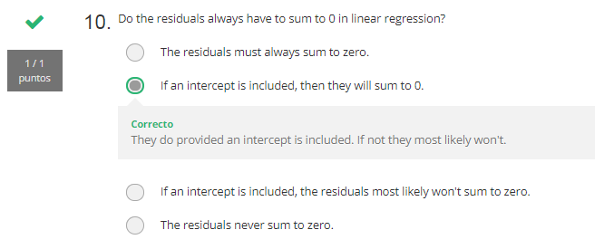

qownnotes-media-NZjjlP

## Regresión multivariable

Cuando se hace un análisis multivariables, es muy importante escoger qué variables van a intervenir en el modelo, y de esa manera eliminar variables de confusión que pueden hacer que la regresón que estamos llevando a cabo sea errónea.

Vamos a comparar una regresión entre la fertilidad comparada con el resto de variables, nos vamos a fijar en su relacción con la agricultura, y luego vamos a ver su relacción excluyendo el resto de variables para ver cómo difiere. Esta todo en porcentajes.

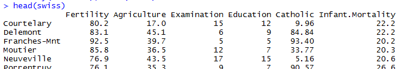

qownnotes-media-AOeeST

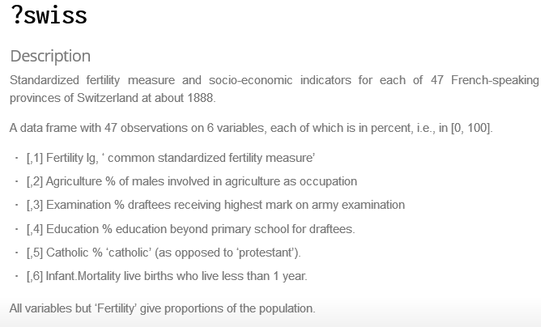

qownnotes-media-uZewce

Se puede hacer gráficamente de dos maneras

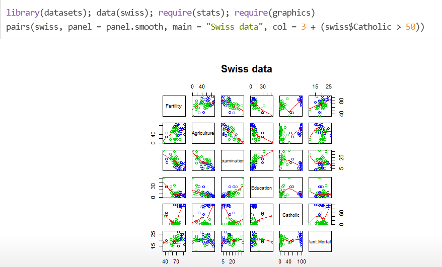

qownnotes-media-KWvukl

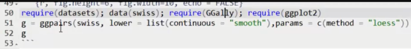

qownnotes-media-NjyqIW

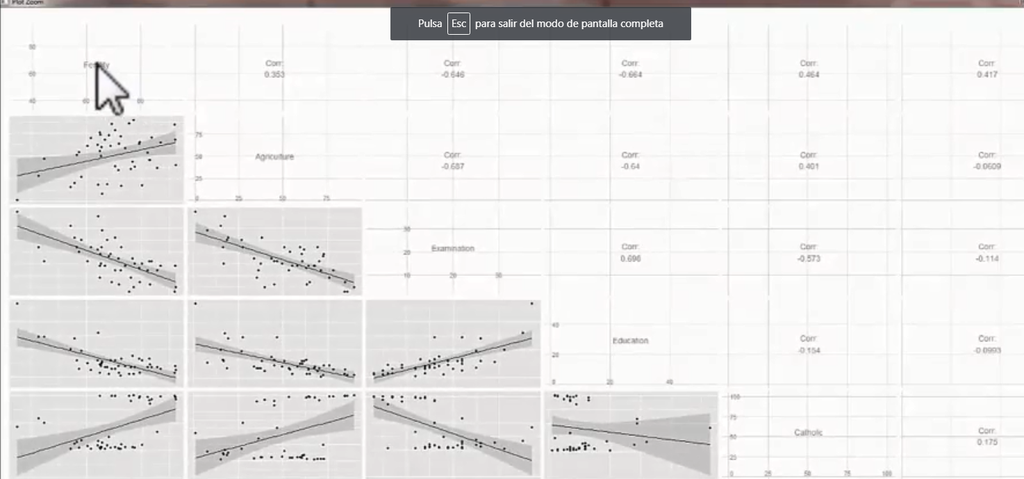

qownnotes-media-dIhRXq

Vamos a hacerlo con lm

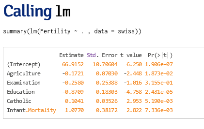

qownnotes-media-AjSkFc

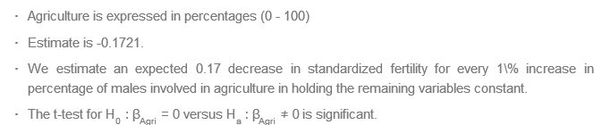

qownnotes-media-FXaRjc

El t value no es más que dividir el estimate/std Errror, y la última columna nos da un p value two sided que nos indica si es estadísticamente significativo

Ahora vamos a analizar la fertilidad y agricultura exclusivamente

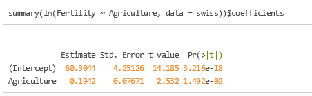

qownnotes-media-rnBQSz

Los resultados son muy distintos, pero incluso me sigue diciendo que es estadisticamente significativo.

Este estudio es algo dinámico, tendremos que ir quitando y poniendo varables para probar su efecto en el modelo.

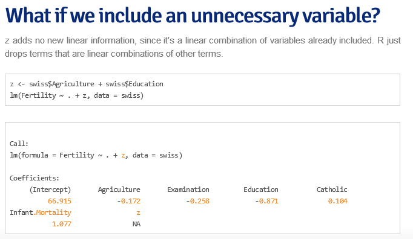

qownnotes-media-nplXCb

lm normalmente nos devuelva NA es porque esa variable es una combinación lineal de otras y no aporta ningún valor al modelo.

**COMPARAR AGRUPACIONES EN VARIABLE CATEGORICA**

Ahora vamos a ver cómo se puede usar lm para comparar resultados frente a una variable factor

En este caso vamos a usar el dataset de insectos, con el spray correspondiente y el número de insectors que mata

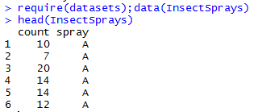

qownnotes-media-OvnTJV

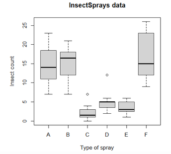

qownnotes-media-UBmJtf

Si no indicamos nada, se toma como referencia del factor el primer grupo, en este caso A, que actuará como Intercep

Linear model fit, group A is the reference

```
{r, echo= TRUE}
summary(lm(count ~ spray, data = InsectSprays))$coef
```

Aquí lo que estamos obteniendo son el el coficiente la diferencia con la media referencia (intercept) y el Pr(t) nos dirá si la diferencia entre los grupos es estadísticamente significativa (vemos en el caso de A y B que no, por ejemplo, como se puede ver en el boxplot).

Aquí estamos asumiendo que estamos tratando con una distribución normal y que la varianza entre los grupos es homogénea, cosa que no es cierta (los valores son siempre mayores que 0) por lo que aquí el pvalue de ttest no será válido, pero nos sirve para ver el ejemplo. Para contar datos será más apropiada Poisson GLM que veremos más adelante.

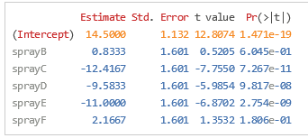

qownnotes-media-ffKRON

Siempre tenemos que comparar con algo, si queremos que sea otra la referencia tenemos que hacer relevel

Reordering the levels

```
{r}
spray2 <- relevel(InsectSprays$spray, "C")
summary(lm(count ~ spray2, data = InsectSprays))$coef
```

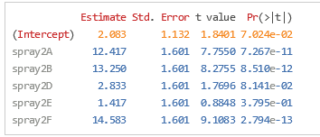

qownnotes-media-DpIsru

Y qué pasaría si omitimos el intercept? En este caso no compararíamos los grupos entre sí y lo estaríamos comparando con 0 como referencia, por tanto los pvalues sería si la diferencia con 0 es estadísticamente significativa, y en los coeficientes únicamente las medias de cada grupo.

What if we omit the intercept?

```
{r, echo= TRUE}
summary(lm(count ~ spray - 1, data = InsectSprays))$coef
unique(ave(InsectSprays$count, InsectSprays$spray))
```

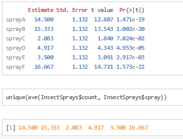

qownnotes-media-xINqMe

**Líneas de regresión por grupos**

Vamos a investigar qué pasa si dos variables que estamos usando interfieren una con la otra. Para simplificarlo usaremos una variable Bimodal en base a la religion, 1 catolico 0 protestante, y vamos a sacar una línea de regresión por cada tipo.

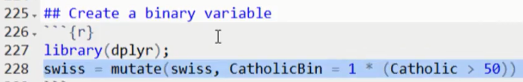

qownnotes-media-KcMfBL

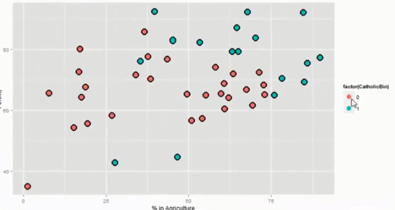

qownnotes-media-kSzOJt

Vamos a sacar una linea de regresión para las provincias con mayoría católica y otra línea para las provincias con mayoría protestante.

Si las variables no interfieren entre ellas tendremos 2 líneas con distinto intercept y misma pendiente:

Modelo 1 .- no se tiene en cuenta religion

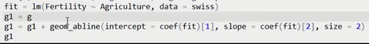

qownnotes-media-UuDtzx

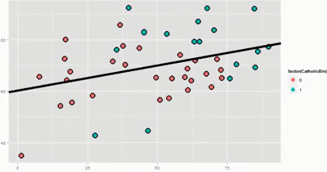

qownnotes-media-yxLdSz

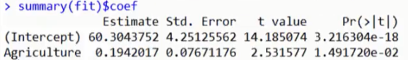

qownnotes-media-jSVfeC

Modelo 2 .- Los grupos de religión no interfieren entre sí

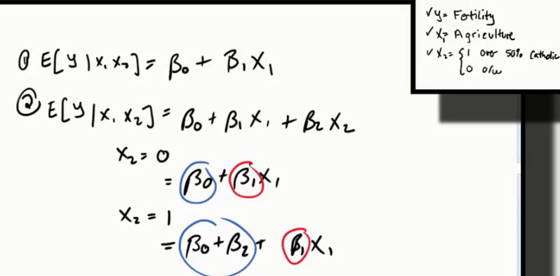

qownnotes-media-LojhDs

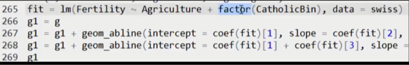

qownnotes-media-RsIVbn

Especificamos que sea factor, porque hay veces que los 0,1,2 los identifica como coeficientes crecientes, que cada valor corresponde al doble del inmediatamente anterior

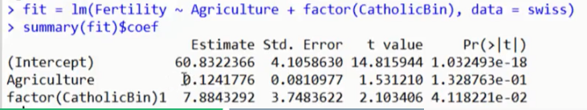

qownnotes-media-sHVqoU

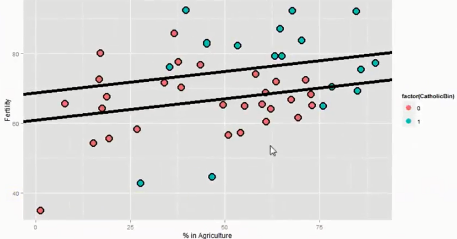

qownnotes-media-CYrSAu

Modelo 3.- Los grupos de religión sí interfieren

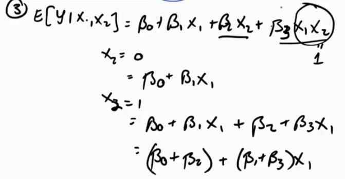

qownnotes-media-lnCMeq

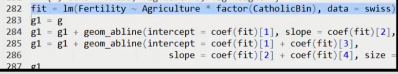

qownnotes-media-VKTKln

Esto lo hacemos con el * , de modo que el primer intercept será de los no catolicos, y el tercer estimador será el intercept de los catolicos, mientras que el segundo y el cuarto serán las pendientes de los no catolicos y catolicos

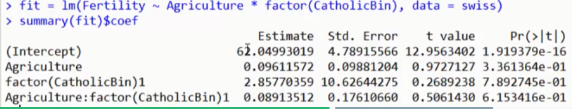

qownnotes-media-XFrChM

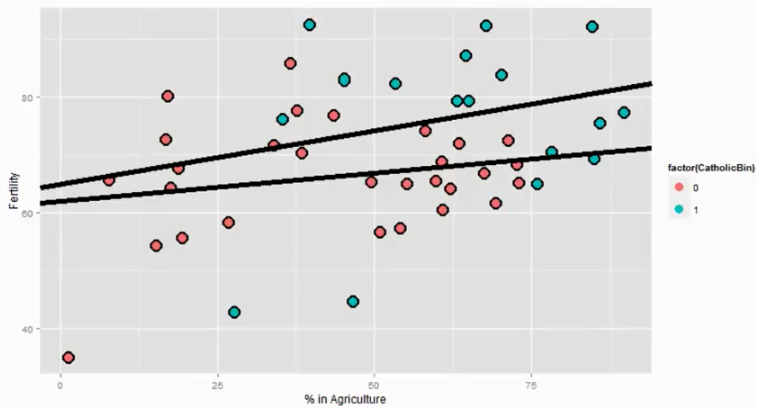

qownnotes-media-nokyRe

This is the third and final lesson in which we’ll look at regression models with more than one independent variable or predictor. We’ll begin with WHO hunger data which we’ve taken the liberty to load for you. WHO is the World Health Organization and this data concerns young children from around the world and rates of hunger among them which the organization compiled over a number of years. The original csv file was very large and we’ve subsetted just the rows which identify the gender of the child as either male or female. We’ve read the data into the data frame “hunger” for you, so you can easily access it.

…

|======= | 5%

As we did in the last lesson let’s first try to get a better understanding of the dataset. Use the R function dim to find the dimensions of hunger.

> dim(hunger) [1] 948 13

Keep working like that and you’ll get there!

|=========== | 8%

How many samples does hunger have?

> 948 [1] 948

That’s the answer I was looking for.

|============== | 11%

Now use the R function names to find out what the 13 columns of hunger represent.

> names(hunger) [1] “X” “Indicator” “Data.Source” “PUBLISH.STATES” “Year” “WHO.region” “Country” “Sex”  
> [9] “Display.Value” “Numeric” “Low” “High” “Comments”

That’s a job well done!

|================== | 14%

The Numeric column for a particular row tells us the percentage of children under age 5 who were underweight when that sample was taken. This is one of the columns we’ll be focussing on in this lesson. It will be the outcome (dependent variable) for the models we generate.

…

|===================== | 16%

Let’s first look at the rate of hunger and see how it’s changed over time. Use the R function lm to generate the linear model in which the rate of hunger, Numeric, depends on the predictor, Year. Put the result in the variable fit.

> fit <- lm(Numeric ~ Year,hunger)

You are amazing!

|========================= | 19%

Now look at the coef portion of the summary of fit.

> summary(fit)$coef Estimate Std. Error t value Pr(>|t|) (Intercept) 634.479660 121.1445995 5.237375 2.007699e-07 Year -0.308397 0.0605292 -5.095012 4.209412e-07

Great job!

|============================ | 22%

What is the coefficient of hunger$Year?

1: -0.30840 2: 634.47966 3: 121.14460 4: 0.06053

Selection: 1

All that practice is paying off!

|================================ | 24%

What does the negative Estimate of hunger$Year show?

1: As time goes on, the rate of hunger increases 2: I haven’t a clue 3: As time goes on, the rate of hunger decreases

Selection: 3

Perseverance, that’s the answer.

|=================================== | 27%

What does the intercept of the model represent?

1: the percentage of hungry children at year 0 2: the number of hungry children at year 0 3: the number of children questioned in the survey

Selection: 1

You’re the best!

|======================================= | 30%

Now let’s use R’s subsetting capability to look at the rates of hunger for the different genders to see how, or even if, they differ. Once again use the R function lm to generate the linear model in which the rate of hunger (Numeric) for female children depends on Year. Put the result in the variable lmF. You’ll have to use the R construct x[hunger$Sex==“Female”] to pick out both the correct Numerics and the correct Years.

> fit <- lm(Numeric ~ Year,hunger[hunger$Sex==“Female”]) Error in `[.data.frame`(hunger, hunger$Sex == "Female") : undefined columns selected fit <- lm(Numeric ~ Year,hunger[,hunger$Sex==“Female”]) Error in `[.data.frame`(hunger, , hunger$Sex == “Female”) : undefined columns selected fit <- lm(Numeric ~ Year,hunger)

You seem to have misspelled the model’s name. I was expecting lmF but you apparently typed fit.

You almost had it, but not quite. Try again. Or, type info() for more options.

Type lmF <- lm(hunger$Numeric[hunger$Sex==“Female”] ~ hunger$Year[hunger$Sex==“Female”]) at the R prompt or more simply lmF <- lm(Numeric[Sex==“Female”] ~ Year[Sex==“Female”],hunger)

> lmF <- lm(hunger$Numeric[hunger$Sex==“Female”] ~ hunger$Year[hunger$Sex==“Female”])

That’s the answer I was looking for.

|========================================== | 32%

Do the same for male children and put the result in lmM.

> lmM <- lm(hunger$Numeric[hunger$Sex==“Male”] ~ hunger$Year[hunger$Sex==“Male”])

That’s the answer I was looking for.

|============================================== | 35%

Now we’ll plot the data points and fitted lines using different colors to distinguish between males (blue) and females (pink).

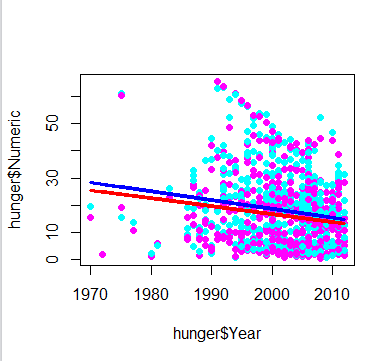

qownnotes-media-tBfMNp

We can see from the plot that the lines are not exactly parallel. On the right side of the graph (around the year 2010) they are closer together than on the left side (around 1970). Since they aren’t parallel, their slopes must be different, though both are negative. Of the following R expressions which would confirm that the slope for males is negative?

1: lmM$coef[1] 2: lmF$coef[2] 3: lmM$coef[2]

Selection: 3

Your dedication is inspiring!

|===================================================== | 41%

Now instead of separating the data by subsetting the samples by gender we’ll use gender as another predictor to create the linear model lmBoth. Recall that to do this in R we place a plus sign “+” between the independent variables, so the formula looks like dependent ~ independent1 + independent2.

…

|======================================================== | 43%

Create lmBoth now. Numeric is the dependent, Year and Sex are the independent variables. The data is “hunger”. For lmBoth, make sure Year is first and Sex is second.

> lmBoth <- lm(Numeric ~ Year+Sex,hunger)

You are doing so well!

|============================================================ | 46%

Now look at the summary of lmBoth with the R command summary.

> summary(lmBoth)

```
Call:
lm(formula = Numeric ~ Year + Sex, data = hunger)

Residuals:
    Min      1Q  Median      3Q     Max
-25.472 -11.297  -1.848   7.058  45.990

Coefficients:
            Estimate Std. Error t value Pr(>|t|)
(Intercept) 633.5283   120.8950   5.240 1.98e-07 ***
Year         -0.3084     0.0604  -5.106 3.99e-07 ***
SexMale       1.9027     0.8576   2.219   0.0267 *
---
Signif. codes:  0 '***' 0.001 '**' 0.01 '*' 0.05 '.' 0.1 ' ' 1

Residual standard error: 13.2 on 945 degrees of freedom
Multiple R-squared:  0.03175,   Adjusted R-squared:  0.0297
F-statistic: 15.49 on 2 and 945 DF,  p-value: 2.392e-07
```

Keep working like that and you’ll get there!

|=============================================================== | 49%

Notice that three estimates are given, the intercept, one for Year and one for Male. What happened to the estimate for Female? Note that Male and Female are categorical variables hence they are factors in this model. Recall from the last lesson (and slides) that R treats the first (alphabetical) factor as the reference and its estimate is the intercept which represents the percentage of hungry females at year 0. The estimate given for the factor Male is a distance from the intercept (the estimate of the reference group Female). To calculate the percentage of hungry males at year 0 you have to add together the intercept and the male estimate given by the model.

…

|=================================================================== | 51%

What percentage of young Males were hungry at year 0?

1: 635.431 2: 633.2199 3: 1.9027 4: I can’t tell since the data starts at 1970.

Selection: 3

Try again. Getting it right on the first try is boring anyway!

The intercept is the percentage of females hungry at year 0 and the intercept plus hunger$SexMale is the percentage of males hungry at year 0.

1: I can’t tell since the data starts at 1970. 2: 635.431 3: 633.2199 4: 1.9027

Selection: 2

You got it right!

|====================================================================== | 54%